# CS 422 HW5

Ramesh Chandra Reddy Musilanna

## 2. Practicum Problems

### 2.1. Association Rules

#### Part 2.1.a

```r
library(arules)
products.df <- read.csv("products.csv", header = FALSE)
```

#### Part 2.1.b

```r
tr1k.df <- read.transactions("tr-1k-canonical.csv",format = 'basket', header = FALSE, sep = ',')
tr5k.df <- read.transactions("tr-5k-canonical.csv",format = 'basket', header = FALSE, sep = ',')
tr20k.df <- read.transactions("tr-20k-canonical.csv",format = 'basket', header = FALSE, sep = ',')
tr75k.df <- read.transactions("tr-75k-canonical.csv",format = 'basket', header = FALSE, sep = ',')
```

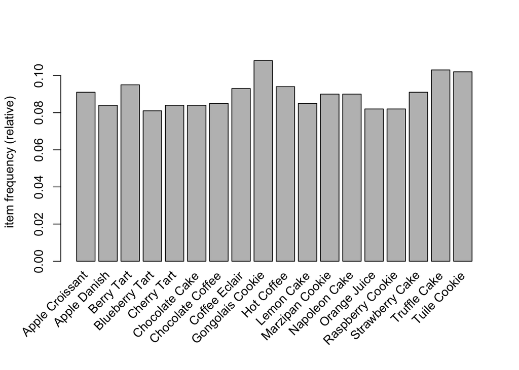

```r
itemFrequencyPlot(tr1k.df, support = 0.080)
```

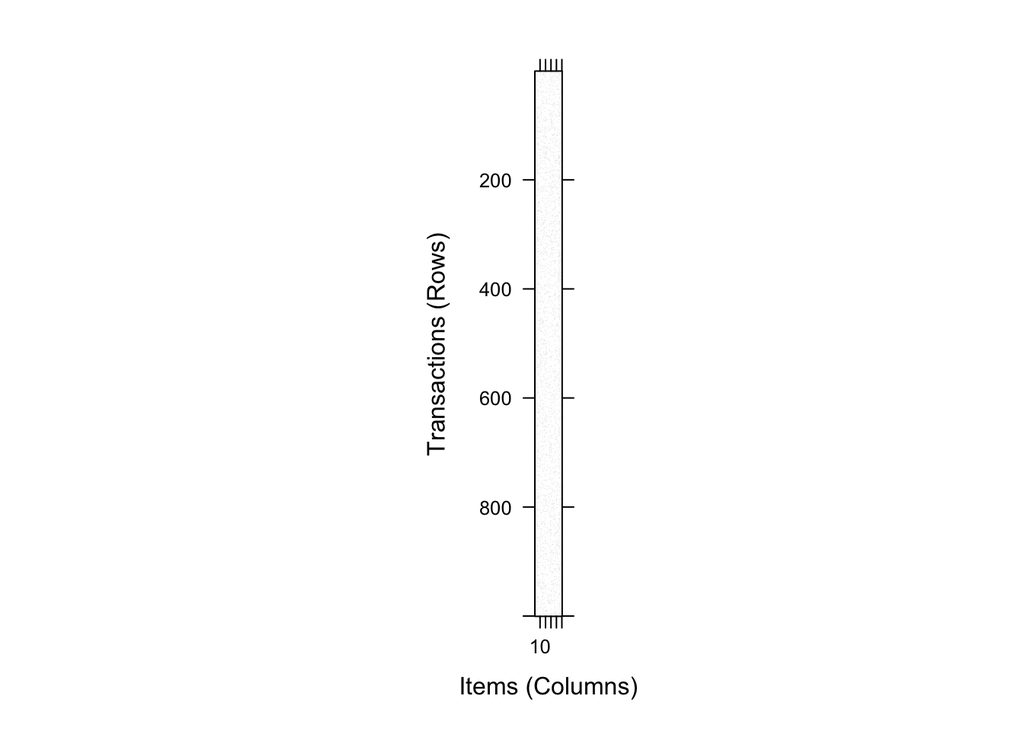

```r
image(tr1k.df)
```

```r
Freq_1k <- apriori(tr1k.df, parameter=list(support=0.01, target="frequent itemsets"))
```

```
## Apriori
##
## Parameter specification:
##  confidence minval smax arem  aval originalSupport maxtime support minlen
##          NA    0.1    1 none FALSE            TRUE       5    0.01      1
##  maxlen            target  ext
##      10 frequent itemsets TRUE
##
## Algorithmic control:
##  filter tree heap memopt load sort verbose
##     0.1 TRUE TRUE  FALSE TRUE    2    TRUE
##
## Absolute minimum support count: 10
##
## set item appearances ...[0 item(s)] done [0.00s].
## set transactions ...[50 item(s), 1000 transaction(s)] done [0.00s].
## sorting and recoding items ... [50 item(s)] done [0.00s].
## creating transaction tree ... done [0.00s].
## checking subsets of size 1 2 3 4 5 done [0.00s].
## sorting transactions ... done [0.00s].
## writing ... [132 set(s)] done [0.00s].
## creating S4 object  ... done [0.00s].
```

```r
inspect(head(Freq_1k, by="support", 10))
```

```
##      items              support count
## [1]  {Gongolais Cookie} 0.108   108
## [2]  {Truffle Cake}     0.103   103
## [3]  {Tuile Cookie}     0.102   102
## [4]  {Berry Tart}       0.095    95
## [5]  {Hot Coffee}       0.094    94
## [6]  {Coffee Eclair}    0.093    93
## [7]  {Strawberry Cake}  0.091    91
## [8]  {Apple Croissant}  0.091    91
## [9]  {Marzipan Cookie}  0.090    90
## [10] {Napoleon Cake}    0.090    90
```

After testing with various minconf values, I found that greatest support value for an itemset is 0.108

```r
rules_1k <- apriori(tr1k.df, parameter=list(support=0.01, confidence = 0.99, target="rules"))
```

```
## Apriori
##
## Parameter specification:
##  confidence minval smax arem  aval originalSupport maxtime support minlen
##        0.99    0.1    1 none FALSE            TRUE       5    0.01      1
##  maxlen target  ext
##      10  rules TRUE
##
## Algorithmic control:
##  filter tree heap memopt load sort verbose
##     0.1 TRUE TRUE  FALSE TRUE    2    TRUE
##
## Absolute minimum support count: 10
##
## set item appearances ...[0 item(s)] done [0.00s].
## set transactions ...[50 item(s), 1000 transaction(s)] done [0.00s].
## sorting and recoding items ... [50 item(s)] done [0.00s].
## creating transaction tree ... done [0.00s].
## checking subsets of size 1 2 3 4 5 done [0.00s].
## writing ... [29 rule(s)] done [0.00s].
## creating S4 object  ... done [0.00s].
```

```r
inspect(head(rules_1k, by="lift", 10))
```

```
##      lhs                       rhs              support confidence coverage     lift count
## [1]  {Vanilla Frappuccino,
##       Walnut Cookie}        => {Chocolate Tart}   0.018          1    0.018 19.60784    18
## [2]  {Apple Pie,
##       Coffee Eclair,
##       Hot Coffee}           => {Almond Twist}     0.024          1    0.024 15.38462    24
## [3]  {Raspberry Cookie,
##       Raspberry Lemonade}   => {Lemon Cookie}     0.029          1    0.029 15.15152    29
## [4]  {Green Tea,
##       Lemon Lemonade,
##       Raspberry Lemonade}   => {Lemon Cookie}     0.019          1    0.019 15.15152    19
## [5]  {Green Tea,
##       Lemon Cookie,
##       Raspberry Lemonade}   => {Lemon Lemonade}   0.019          1    0.019 15.15152    19
## [6]  {Green Tea,
##       Lemon Lemonade,
##       Raspberry Cookie}     => {Lemon Cookie}     0.019          1    0.019 15.15152    19
## [7]  {Green Tea,
##       Lemon Cookie,
##       Raspberry Cookie}     => {Lemon Lemonade}   0.019          1    0.019 15.15152    19
## [8]  {Green Tea,
##       Raspberry Cookie,
##       Raspberry Lemonade}   => {Lemon Lemonade}   0.019          1    0.019 15.15152    19
## [9]  {Lemon Lemonade,
##       Raspberry Cookie,
##       Raspberry Lemonade}   => {Lemon Cookie}     0.028          1    0.028 15.15152    28
## [10] {Green Tea,
##       Raspberry Cookie,
##       Raspberry Lemonade}   => {Lemon Cookie}     0.019          1    0.019 15.15152    19
```

One of the rule from above dataset based on high lift value is that customers who bought Walnut Cookie and Vanilla Frappuccino have likely chance to buy Chocolate Tart.

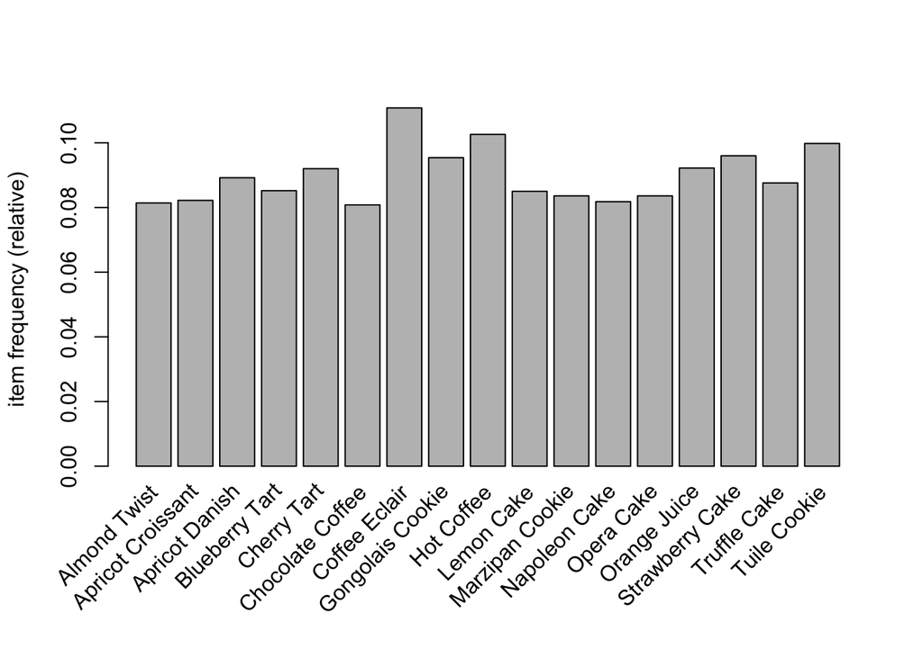

```r
itemFrequencyPlot(tr5k.df, support = 0.080)
```

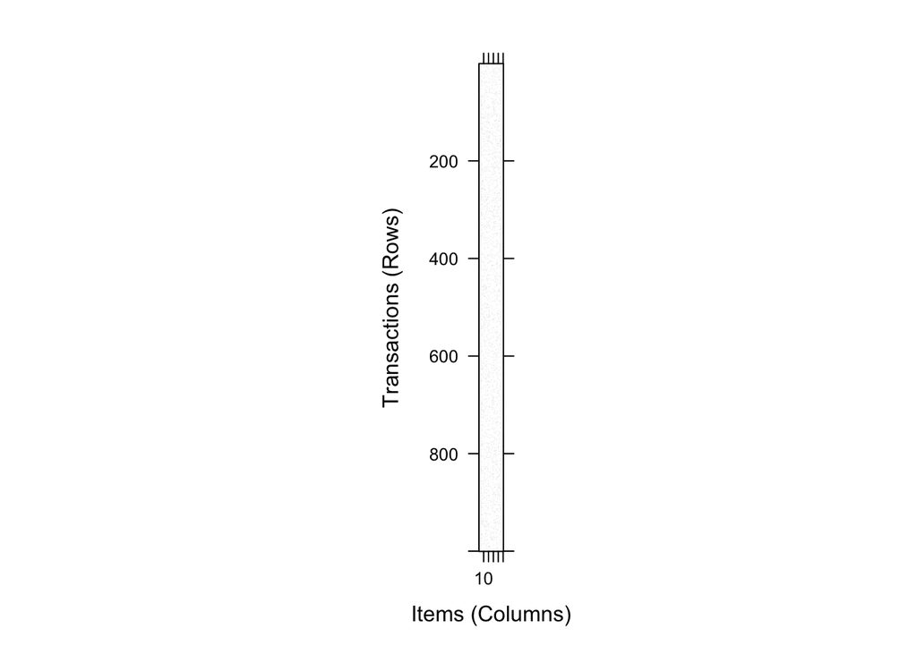

```r
image(tr1k.df)
```

```r
Freq_5k <- apriori(tr5k.df, parameter=list(support=0.01, target="frequent itemsets"))
```

```
## Apriori
##
## Parameter specification:
##  confidence minval smax arem  aval originalSupport maxtime support minlen
##          NA    0.1    1 none FALSE            TRUE       5    0.01      1
##  maxlen            target  ext
##      10 frequent itemsets TRUE
##
## Algorithmic control:
##  filter tree heap memopt load sort verbose
##     0.1 TRUE TRUE  FALSE TRUE    2    TRUE
##
## Absolute minimum support count: 50
##
## set item appearances ...[0 item(s)] done [0.00s].
## set transactions ...[50 item(s), 5000 transaction(s)] done [0.00s].
## sorting and recoding items ... [50 item(s)] done [0.00s].
## creating transaction tree ... done [0.00s].
## checking subsets of size 1 2 3 4 5 done [0.00s].
## sorting transactions ... done [0.00s].
## writing ... [124 set(s)] done [0.00s].
## creating S4 object  ... done [0.00s].
```

```r
inspect(head(Freq_5k, by="support", 10))
```

```
##      items              support count
## [1]  {Coffee Eclair}    0.1108  554
## [2]  {Hot Coffee}       0.1026  513
## [3]  {Tuile Cookie}     0.0998  499
## [4]  {Strawberry Cake}  0.0960  480
## [5]  {Gongolais Cookie} 0.0954  477
## [6]  {Orange Juice}     0.0922  461
## [7]  {Cherry Tart}      0.0920  460
## [8]  {Apricot Danish}   0.0892  446
## [9]  {Truffle Cake}     0.0876  438
## [10] {Blueberry Tart}   0.0852  426
```

In the Dataset with 5000 rows Coffee Eclair topped with higher support values

```r
rules_5k <- apriori(tr5k.df, parameter=list(support=0.01, confidence = 0.99, target="rules"))
```

```
## Apriori
##
## Parameter specification:
##  confidence minval smax arem  aval originalSupport maxtime support minlen
##        0.99    0.1    1 none FALSE            TRUE       5    0.01      1
##  maxlen target  ext
##      10  rules TRUE
##
## Algorithmic control:
##  filter tree heap memopt load sort verbose
##     0.1 TRUE TRUE  FALSE TRUE    2    TRUE
##
## Absolute minimum support count: 50
##
## set item appearances ...[0 item(s)] done [0.00s].
## set transactions ...[50 item(s), 5000 transaction(s)] done [0.00s].
## sorting and recoding items ... [50 item(s)] done [0.00s].
## creating transaction tree ... done [0.00s].
## checking subsets of size 1 2 3 4 5 done [0.00s].
## writing ... [26 rule(s)] done [0.00s].
## creating S4 object  ... done [0.00s].
```

```r
inspect(head(rules_5k, by="lift", 10))
```

```
##      lhs                     rhs                support confidence coverage     lift count
## [1]  {Green Tea,
##       Lemon Lemonade,
##       Raspberry Lemonade} => {Raspberry Cookie}  0.0212  1.0000000   0.0212 15.62500   106
## [2]  {Green Tea,
##       Lemon Cookie,
##       Raspberry Lemonade} => {Raspberry Cookie}  0.0212  1.0000000   0.0212 15.62500   106
## [3]  {Green Tea,
##       Lemon Cookie,
##       Lemon Lemonade,
##       Raspberry Lemonade} => {Raspberry Cookie}  0.0212  1.0000000   0.0212 15.62500   106
## [4]  {Green Tea,
##       Lemon Lemonade,
##       Raspberry Cookie}   => {Lemon Cookie}      0.0212  1.0000000   0.0212 15.57632   106
## [5]  {Green Tea,
##       Lemon Lemonade,
##       Raspberry Lemonade} => {Lemon Cookie}      0.0212  1.0000000   0.0212 15.57632   106
## [6]  {Green Tea,
##       Raspberry Cookie,
##       Raspberry Lemonade} => {Lemon Cookie}      0.0212  1.0000000   0.0212 15.57632   106
## [7]  {Lemon Lemonade,
##       Raspberry Cookie,
##       Raspberry Lemonade} => {Lemon Cookie}      0.0262  1.0000000   0.0262 15.57632   131
## [8]  {Green Tea,
##       Lemon Lemonade,
##       Raspberry Cookie,
##       Raspberry Lemonade} => {Lemon Cookie}      0.0212  1.0000000   0.0212 15.57632   106
## [9]  {Lemon Cookie,
##       Lemon Lemonade,
##       Raspberry Lemonade} => {Raspberry Cookie}  0.0262  0.9924242   0.0264 15.50663   131
## [10] {Green Tea,
##       Lemon Cookie,
##       Lemon Lemonade}     => {Raspberry Cookie}  0.0212  0.9906542   0.0214 15.47897   106
```

One of the rule from above dataset based on high lift values is that customers who bought Green tea, Lemon lemonade and Raspberry Lemonade have chance to buy Raspberry cookie or lemon cookie

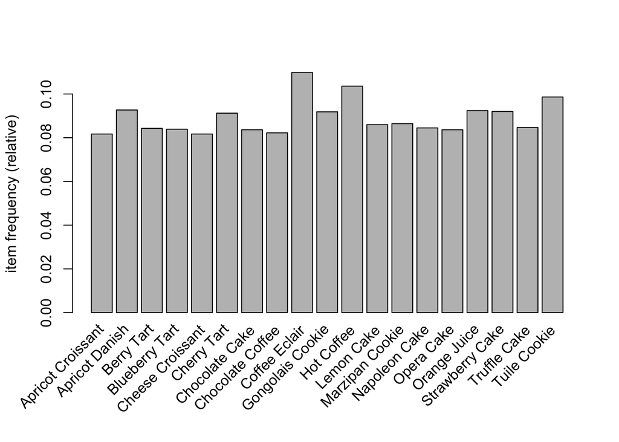

```r
itemFrequencyPlot(tr20k.df, support = 0.080)
```

[figure not shown]

```r
image(tr20k.df)
```

```r
Freq_20k <- apriori(tr20k.df, parameter=list(support=0.01, target="frequent itemsets"))
```

```
## Apriori
##
## Parameter specification:
##  confidence minval smax arem  aval originalSupport maxtime support minlen
##          NA    0.1    1 none FALSE            TRUE       5    0.01      1
##  maxlen            target  ext
##      10 frequent itemsets TRUE
##
## Algorithmic control:
##  filter tree heap memopt load sort verbose
##     0.1 TRUE TRUE  FALSE TRUE    2    TRUE
##
## Absolute minimum support count: 200
##
## set item appearances ...[0 item(s)] done [0.00s].
## set transactions ...[50 item(s), 20000 transaction(s)] done [0.00s].
## sorting and recoding items ... [50 item(s)] done [0.00s].
## creating transaction tree ... done [0.00s].
## checking subsets of size 1 2 3 4 5 done [0.00s].
## sorting transactions ... done [0.00s].
## writing ... [124 set(s)] done [0.00s].
## creating S4 object  ... done [0.00s].
```

```r
inspect(head(Freq_20k, by="support", 10))
```

```
##      items              support count
## [1]  {Coffee Eclair}    0.10985 2197
## [2]  {Hot Coffee}       0.10360 2072
## [3]  {Tuile Cookie}     0.09865 1973
## [4]  {Apricot Danish}   0.09270 1854
## [5]  {Orange Juice}     0.09240 1848
## [6]  {Strawberry Cake}  0.09200 1840
## [7]  {Gongolais Cookie} 0.09185 1837
## [8]  {Cherry Tart}      0.09125 1825
## [9]  {Marzipan Cookie}  0.08645 1729
## [10] {Lemon Cake}       0.08600 1720
```

Coffee Eclair still topped in 20K transaction dataset.

```r
rules_20k <- apriori(tr20k.df, parameter=list(support=0.01, confidence = 0.99, target="rules"))
```

```
## Apriori
##
## Parameter specification:
##  confidence minval smax arem  aval originalSupport maxtime support minlen
##        0.99    0.1    1 none FALSE            TRUE       5    0.01      1
##  maxlen target  ext
##      10  rules TRUE
##
## Algorithmic control:
##  filter tree heap memopt load sort verbose
##     0.1 TRUE TRUE  FALSE TRUE    2    TRUE
##
## Absolute minimum support count: 200
##
## set item appearances ...[0 item(s)] done [0.00s].
## set transactions ...[50 item(s), 20000 transaction(s)] done [0.00s].
## sorting and recoding items ... [50 item(s)] done [0.00s].
## creating transaction tree ... done [0.00s].
## checking subsets of size 1 2 3 4 5 done [0.00s].
## writing ... [24 rule(s)] done [0.00s].
## creating S4 object  ... done [0.00s].
```

```r
inspect(head(rules_20k, by="lift", 10))
```

```
##      lhs                     rhs                  support confidence coverage     lift count
## [1]  {Green Tea,
##       Lemon Cookie,
##       Raspberry Cookie,
##       Raspberry Lemonade} => {Lemon Lemonade}     0.02040  1.0000000  0.02040 15.02630   408
## [2]  {Green Tea,
##       Raspberry Cookie,
##       Raspberry Lemonade} => {Lemon Lemonade}     0.02045  0.9975610  0.02050 14.98965   409
## [3]  {Green Tea,
##       Lemon Cookie,
##       Raspberry Lemonade} => {Lemon Lemonade}     0.02045  0.9951338  0.02055 14.95318   409
## [4]  {Lemon Cookie,
##       Raspberry Cookie,
##       Raspberry Lemonade} => {Lemon Lemonade}     0.02545  0.9941406  0.02560 14.93825   509
## [5]  {Green Tea,
##       Lemon Cookie,
##       Raspberry Cookie}   => {Lemon Lemonade}     0.02040  0.9927007  0.02055 14.91662   408
## [6]  {Apple Croissant,
##       Apple Tart,
##       Cherry Soda}        => {Apple Danish}       0.02100  0.9929078  0.02115 14.69886   420
## [7]  {Green Tea,
##       Lemon Lemonade,
##       Raspberry Cookie,
##       Raspberry Lemonade} => {Lemon Cookie}       0.02040  0.9975550  0.02045 14.61619   408
## [8]  {Green Tea,
##       Lemon Cookie,
##       Lemon Lemonade,
##       Raspberry Cookie}   => {Raspberry Lemonade} 0.02040  1.0000000  0.02040 14.60920   408
## [9]  {Green Tea,
##       Lemon Lemonade,
##       Raspberry Lemonade} => {Lemon Cookie}       0.02045  0.9951338  0.02055 14.58072   409
## [10] {Green Tea,
##       Raspberry Cookie,
##       Raspberry Lemonade} => {Lemon Cookie}       0.02040  0.9951220  0.02050 14.58054   408
```

Some of the rules from above dataset based on high lift values is that customers who bought Green tea, Lemon lemonade and Raspberry Lemonade have chance to buy Raspberry cookie or lemon cookie and other is Customers who bought Apple Croissant, Apple Tart and Cherry Soda are likely to buy Apple Danish.

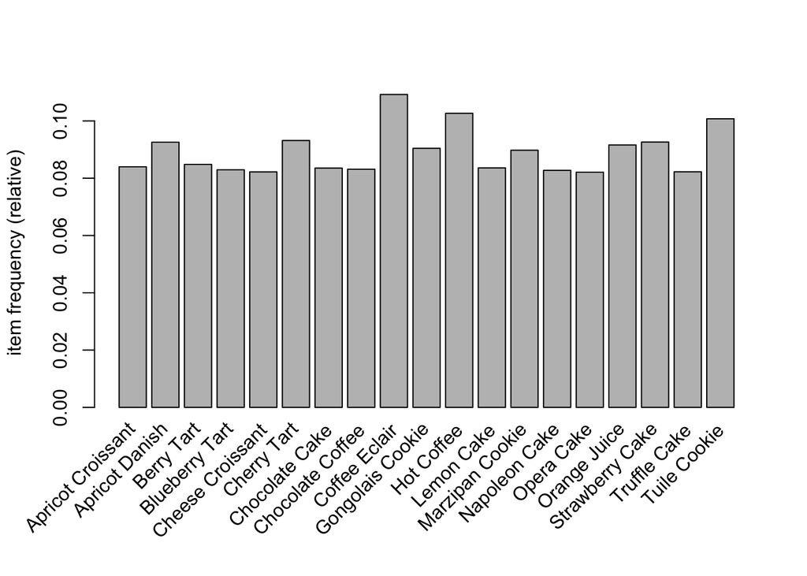

```r
itemFrequencyPlot(tr75k.df, support = 0.080)
```

[figure not shown]

```r
image(tr75k.df)
```

```r
Freq_75k <- apriori(tr75k.df, parameter=list(support=0.01, target="frequent itemsets"))
```

```
## Apriori
##
## Parameter specification:
##  confidence minval smax arem  aval originalSupport maxtime support minlen
##          NA    0.1    1 none FALSE            TRUE       5    0.01      1
##  maxlen            target  ext
##      10 frequent itemsets TRUE
##
## Algorithmic control:
##  filter tree heap memopt load sort verbose
##     0.1 TRUE TRUE  FALSE TRUE    2    TRUE
##
## Absolute minimum support count: 750
##
## set item appearances ...[0 item(s)] done [0.00s].
## set transactions ...[50 item(s), 75000 transaction(s)] done [0.01s].
## sorting and recoding items ... [50 item(s)] done [0.00s].
## creating transaction tree ... done [0.02s].
## checking subsets of size 1 2 3 4 5 done [0.01s].
## sorting transactions ... done [0.01s].
## writing ... [124 set(s)] done [0.00s].
## creating S4 object  ... done [0.00s].
```

```r
inspect(head(Freq_75k, by="support", 10))
```

```
##      items              support    count
## [1]  {Coffee Eclair}    0.10924000 8193
## [2]  {Hot Coffee}       0.10266667 7700
## [3]  {Tuile Cookie}     0.10074667 7556
## [4]  {Cherry Tart}      0.09316000 6987
## [5]  {Strawberry Cake}  0.09264000 6948
## [6]  {Apricot Danish}   0.09257333 6943
## [7]  {Orange Juice}     0.09161333 6871
## [8]  {Gongolais Cookie} 0.09044000 6783
## [9]  {Marzipan Cookie}  0.08977333 6733
## [10] {Berry Tart}       0.08482667 6362
```

Coffee Eclair still topped in 75K transaction dataset aswell.

```r
rules_75k <- apriori(tr75k.df, parameter=list(support=0.01, confidence = 0.99, target="rules"))
```

```
## Apriori
##
## Parameter specification:
##  confidence minval smax arem  aval originalSupport maxtime support minlen
##        0.99    0.1    1 none FALSE            TRUE       5    0.01      1
##  maxlen target  ext
##      10  rules TRUE
##
## Algorithmic control:
##  filter tree heap memopt load sort verbose
##     0.1 TRUE TRUE  FALSE TRUE    2    TRUE
##
## Absolute minimum support count: 750
##
## set item appearances ...[0 item(s)] done [0.00s].
## set transactions ...[50 item(s), 75000 transaction(s)] done [0.01s].
## sorting and recoding items ... [50 item(s)] done [0.00s].
## creating transaction tree ... done [0.02s].
## checking subsets of size 1 2 3 4 5 done [0.01s].
## writing ... [25 rule(s)] done [0.00s].
## creating S4 object  ... done [0.00s].
```

```r
inspect(head(rules_75k, by="lift", 10))
```

```
##      lhs                     rhs                     support confidence   coverage     lift count
## [1]  {Green Tea,
##       Lemon Cookie,
##       Lemon Lemonade,
##       Raspberry Lemonade} => {Raspberry Cookie}   0.02073333  1.0000000 0.02073333 14.78415  1555
## [2]  {Green Tea,
##       Lemon Cookie,
##       Lemon Lemonade,
##       Raspberry Cookie}   => {Raspberry Lemonade} 0.02073333  1.0000000 0.02073333 14.76087  1555
## [3]  {Apple Danish,
##       Apple Tart,
##       Cherry Soda}        => {Apple Croissant}    0.02058667  0.9929260 0.02073333 14.75519  1544
## [4]  {Green Tea,
##       Lemon Lemonade,
##       Raspberry Lemonade} => {Raspberry Cookie}   0.02074667  0.9974359 0.02080000 14.74624  1556
## [5]  {Lemon Cookie,
##       Lemon Lemonade,
##       Raspberry Lemonade} => {Raspberry Cookie}   0.02556000  0.9973985 0.02562667 14.74569  1917
## [6]  {Green Tea,
##       Lemon Cookie,
##       Raspberry Cookie}   => {Raspberry Lemonade} 0.02073333  0.9980745 0.02077333 14.73245  1555
## [7]  {Green Tea,
##       Lemon Cookie,
##       Lemon Lemonade}     => {Raspberry Cookie}   0.02073333  0.9942455 0.02085333 14.69908  1555
## [8]  {Green Tea,
##       Lemon Lemonade,
##       Raspberry Cookie,
##       Raspberry Lemonade} => {Lemon Cookie}       0.02073333  0.9993573 0.02074667 14.69355  1555
## [9]  {Green Tea,
##       Lemon Lemonade,
##       Raspberry Cookie}   => {Raspberry Lemonade} 0.02074667  0.9942492 0.02086667 14.67599  1556
## [10] {Green Tea,
##       Lemon Cookie,
##       Lemon Lemonade}     => {Raspberry Lemonade} 0.02073333  0.9942455 0.02085333 14.67593  1555
```

#### Part 2.1.c

Data sets with 5k, 20k, 75k are more generalized than 1k data set. by observing items that are apple flavored. we can see that with addition of more transactions rules seems to be robust and generalized.

#### Part 2.1.d.i

```r
inspect(head(Freq_75k, by="support", 10))
```

```
##      items              support    count
## [1]  {Coffee Eclair}    0.10924000 8193
## [2]  {Hot Coffee}       0.10266667 7700
## [3]  {Tuile Cookie}     0.10074667 7556
## [4]  {Cherry Tart}      0.09316000 6987
## [5]  {Strawberry Cake}  0.09264000 6948
## [6]  {Apricot Danish}   0.09257333 6943
## [7]  {Orange Juice}     0.09161333 6871
## [8]  {Gongolais Cookie} 0.09044000 6783
## [9]  {Marzipan Cookie}  0.08977333 6733
## [10] {Berry Tart}       0.08482667 6362
```

Most frequently bought item is Coffee Eclair

#### Part 2.1.d.ii

```r
q <- sort(Freq_75k)
inspect(tail(q))
```

```
##     items                   support count
## [1] {Apple Danish,
##      Apple Tart,
##      Cherry Soda}        0.02073333  1555
## [2] {Green Tea,
##      Lemon Cookie,
##      Raspberry Cookie,
##      Raspberry Lemonade} 0.02073333  1555
## [3] {Green Tea,
##      Lemon Cookie,
##      Lemon Lemonade,
##      Raspberry Cookie}   0.02073333  1555
## [4] {Green Tea,
##      Lemon Cookie,
##      Lemon Lemonade,
##      Raspberry Lemonade} 0.02073333  1555
## [5] {Green Tea,
##      Lemon Cookie,
##      Lemon Lemonade,
##      Raspberry Cookie,
##      Raspberry Lemonade} 0.02073333  1555
## [6] {Apple Croissant,
##      Apple Danish,
##      Apple Tart,
##      Cherry Soda}        0.02058667  1544
```

Least Frequent bought item set is Apple Croissant, Apple Danish, Apple Tart, Cherry Soda.